# Assignment

Matteo Gambera

9 aprile 2020

# Summary

One thing that people regularly do is quantify how much of a particular activity they do, but they rarely quantify how well they do it. In this project, the goal will be to use data from accelerometers on the belt, forearm, arm, and dumbbell of 6 participants. The goal of the project is to predict the manner in which they did the exercise. This is the “classe” variable in the training set.

# Protocol

## Model

Participants were asked to perform one set of 10 repetitions of the Unilateral Dumbbell Biceps Curl in five different fashions:

- Class A: exactly according to the specification,
- Class B: throwing the elbows to the front,
- Class C: lifting the dumbbell only halfway,
- Class D: lowering the dumbbell only halfway,
- Class E: throwing the hips to the front.

Class A corresponds to the specified execution of the exercise, while the other 4 classes correspond to common mistakes.

## Cross-Validation

Will be performed by subsampling the training data set randomly without replacement into 2 subsamples: subTraining data (70% of the original Training data set) and subTesting data (30%). Our models will be fitted on the subTraining data set, and tested on the subTesting data. Once the most accurate model is choosen, it will be tested on the original Testing data set.

## Reproducibility and Library

The pseudo-random number generator seed was set at 1 for all code. For this project load this library.

```r
##Seed
set.seed(1)

##Libraries
library(caret)
library(randomForest)
library(rpart)
library(rattle)
```

```r
library(RColorBrewer)
library(ggplot2)
```

# Data

The training data for this project are available here:

- **[training](https://d396qusza40orc.cloudfront.net/predmachlearn/pml-training.csv)**

The test data are available here:

- **[testing](https://d396qusza40orc.cloudfront.net/predmachlearn/pml-testing.csv)**

The data for this project come from this source: **[link](http://web.archive.org/web/20161224072740/http:/groupware.les.inf.puc-rio.br/har)**. If you use the document you create for this class for any purpose please cite them as they have been very generous in allowing their data to be used for this kind of assignment.

## Getting Data

```r
library(data.table)

## Data training
url_data <- "https://d396qusza40orc.cloudfront.net/predmachlearn/pml-training.csv"
data <- fread(url_data,
              na.strings = c("NA,",""))

## Data testing
url_validation <- "https://d396qusza40orc.cloudfront.net/predmachlearn/pml-testing.csv"
validation <- fread(url_validation,
                    na.strings = c("NA", ""))
```

## Cleaning Data

look at the structure of training data and delete columns with all missing values or irrelevant data.

```r
## Training and testing
MissingValues <- sapply(data, function (x) any(is.na(x) | x == ""))
Predictor <- !MissingValues & grepl("belt|[^(fore)]arm|dumbbell|forearm",
                                    names(MissingValues))
predCandidates <- names(MissingValues)[Predictor]
varToInclude <- c("classe", predCandidates)
data <- data[,varToInclude, with = FALSE]
paste0("dimension data pre cleaning: ",dim(data))
```

```
## [1] "dimension data pre cleaning: 19622" "dimension data pre cleaning: 120"
```

```r
data[,.N,classe]
```

| classe | N |
| --- | --- |
| A | 5580 |
| B | 3797 |
| C | 3422 |
| D | 3216 |
| E | 3607 |

```r
myDataNZV <- nearZeroVar(data, saveMetrics=TRUE)
data <- subset(data, select = which(myDataNZV$nzv == FALSE))
paste0("dimensione data post cleaning: ",dim(data))
```

```
## [1] "dimensione data post cleaning: 19622"
## [2] "dimensione data post cleaning: 53"
```

## Partition the data set

Partition the data set in two data sets

- training 70%
- testing 30%

```r
inTrain <- createDataPartition(y = data$classe, p = 0.7,
                               list = FALSE)
training <- data[inTrain, ]
testing <- data[-inTrain, ]
dim(training); dim(testing)
```

```
## [1] 13737    53
```

```
## [1] 5885   53
```

# Prediction model

```r
trainCtrl <- trainControl(method = "cv", number = 2)

set.seed(1)
modRf <- train(classe ~ ., method = "rf", data = training,
               trControl = trainCtrl)
set.seed(1)
modGbm <- train(classe ~ ., method="gbm", data = training,
                trControl = trainCtrl)
```

Before we use these models to predict classes on the test set, we compare their resampling distributions (noting that there are 2 resamples for each model as we used 2-fold cross-validation) to get a general idea of the difference in performance between the models, and to estimate the out of sample error.

```r
# collect resamples
results <- resamples(list(RF=modRf, GBM=modGbm))

# summary of the resampling distributions
summary(results)
```

```
##
## Call:
## summary.resamples(object = results)
##
## Models: RF, GBM
## Number of resamples: 2
##
## Accuracy
##          Min.   1st Qu.    Median      Mean   3rd Qu.      Max. NA's
## RF  0.9819453 0.9832561 0.9845670 0.9845670 0.9858779 0.9871888    0
## GBM 0.9558824 0.9569394 0.9579965 0.9579965 0.9590536 0.9601106    0
##
## Kappa
##          Min.   1st Qu.    Median      Mean   3rd Qu.      Max. NA's
## RF  0.9771553 0.9788156 0.9804759 0.9804759 0.9821362 0.9837964    0
## GBM 0.9441862 0.9455198 0.9468535 0.9468535 0.9481871 0.9495208    0
```

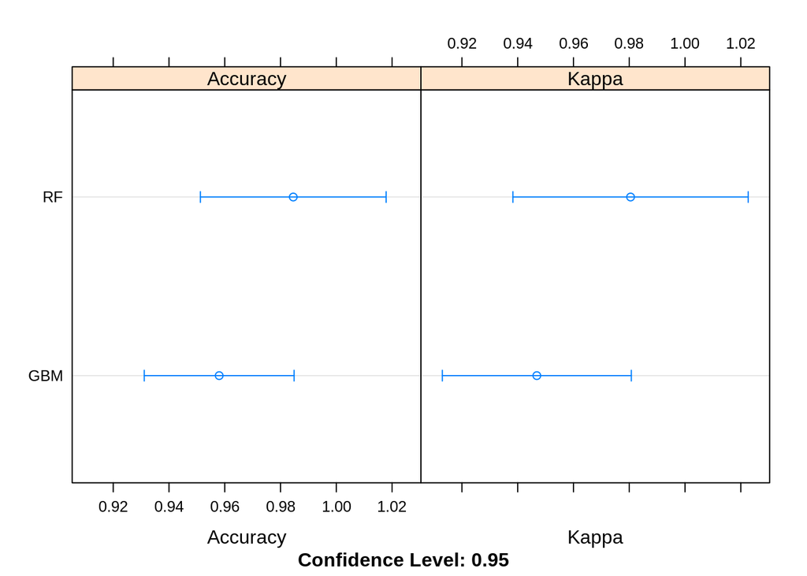

```r
dotplot(results)
```

We now use the models to predict the class of the activities in the testing data set, and calculate the accuracy (or, equivalently, the out of sample error) of the models on this set.

```r
# random forest
predRfTest <- predict(modRf, newdata=testing)
confusionMatrix(as.factor(testing$classe), predRfTest)$table
```

```
##           Reference
## Prediction    A    B    C    D    E
##          A 1670    3    1    0    0
##          B    5 1133    0    1    0
##          C    0   13 1006    7    0
##          D    0    0   14  949    1
##          E    1    1    0    2 1078
```

```r
# boosted trees
predGbmTest <- predict(modGbm, newdata=testing)
confusionMatrix(as.factor(testing$classe), predGbmTest)$table
```

```
##           Reference
## Prediction    A    B    C    D    E
##          A 1638   20   13    1    2
##          B   35 1074   28    2    0
##          C    0   38  967   17    4
##          D    0    3   35  919    7
##          E    1   12    5   21 1043
```

The accuracy of the random forest model is excellent, and the accuracy of the boosted trees model is also very good.

We then fit a model that combines the two best predictors, namely those produced by the random forest model and the boosted trees model, using a random forest, on the test set.

```r
# fit the combination
predRfGbmTest <- data.frame(predRf = predRfTest, predGbm = predGbmTest,
                            classe=testing$classe)
modCombRfGbm <- train(classe ~ ., model = "rf", data=predRfGbmTest,
                 trControl = trainCtrl)
# predict on testing
predCombPredTest <- predict(modCombRfGbm, predRfGbmTest)
```

```r
# first predict using the random forest and boosted trees models
predRfValidation <- predict(modRf, newdata=testing)
predGbmValidation <- predict(modGbm, newdata=testing)

# feed these predictions into our final model
predCombRfGbmValidation <- predict(modCombRfGbm,
                              newdata=data.frame(predRf = predRfValidation,
                                                 predGbm = predGbmValidation))

# confusion matrix
cmCombRfGbmValidation <- confusionMatrix(as.factor(testing$classe),
                                         predCombRfGbmValidation)
cmCombRfGbmValidation$table
```

```
##           Reference
## Prediction    A    B    C    D    E
##          A 1670    3    1    0    0
##          B    5 1133    0    1    0
##          C    0   13 1006    7    0
##          D    0    0   14  949    1
##          E    1    1    0    2 1078
```

```r
# accuracy, out of sample error, kappa on validation set
accCombRfGbmValidation <- cmCombRfGbmValidation$overall[['Accuracy']]
oseCombRfGbmValidation <- 1-accCombRfGbmValidation
kappaCombRfGbmValidation  <- cmCombRfGbmValidation$overall[['Kappa']]
```

# Predictions

```r
predTestCasesRf <- predict(modRf, newdata=validation)
predTestCasesGbm <- predict(modGbm, newdata=validation)

# prediction
predTestCasesCombModFit <- predict(modCombRfGbm,
                                   newdata = data.frame(
                                     predRf = predTestCasesRf,
                                     predGbm = predTestCasesGbm))
predTestCasesCombModFit
```

```
##  [1] B A B A A E D B A A B C B A E E A B B B
## Levels: A B C D E
```